# Uso da regressão linear múltipla para explicar a intenção de voto para Deputado Federal nas eleições de 2010

Eduardo Henrique, Matheus Araújo e Tharyck Souto.

# 1 Explicando o Banco de dados

A cada quatro anos ocorrem eleicões para governador, deputado, senador e presidente. Existe alguma forma de predizer ou ao menos explicarmos como um determnado candidato pode obter muitos **votos**? Para Verificar isso vamos analisar os dados das eleicões para deputado (estadual e federal) em 2010. O estudo esta dividido em basicamente três partes:

- Análise Descritiva dos Dados
- Análise de Regressão Linear
- Análise de Resíduos

## 1.1 Usando o R

Para este trabalho, utilizamos R e Rstudio para o desenvolvimento e ilustração de material produzido.

# 2 Importando as livarias e os dados nescessárias

## 2.1 Importando as livrarias

```r
library(dataPreparation)
library(gridExtra)
library(tidyverse)
library(GGally)
library(caret)
library(broom)
library(here)
library("lmtest")
library(car)
library(dplyr)
```

## 2.2 Importação dos Dados

```r
eleicoes_2010 <- readr::read_csv(
  here::here('eleicoes_2010.csv'),
  local=readr::locale("br"),
  col_types = cols(
    ano = col_integer(), # ano de referencia
    sequencial_candidato = col_character(), # id do candidato
    quantidade_doacoes = col_integer(),
    quantidade_doadores = col_integer(), # número de doadores diferentes
    total_receita = col_double(), # soma em R$ das doações
    media_receita = col_double(), # média das doações
    recursos_de_outros_candidatos.comites = col_double(), # quantia em R$ das doações provenientes de outros candidatos ou comite partidário
    recursos_de_pessoas_fisicas = col_double(), # quantia em R$ das doações provenientes de outros CPFs
    recursos_de_pessoas_juridicas = col_double(), # quantia em R$ das doações provenientes de outros CNPJ
    recursos_proprios = col_double(), # quantia em R$ das doações provenientes do próprio candidato
    `recursos_de_partido_politico` = col_double(), # quantia em R$ das doações provenientes do partido político do candidato
    quantidade_despesas = col_integer(),
    quantidade_fornecedores = col_integer(), # número de fornecedores/despesas diferentes
    total_despesa = col_double(), # soma em R$ das despesas de campanha
    media_despesa = col_double(), # média das despesas de campanha
    votos = col_integer(), #  variável alvo. Se refere ao número de votos na campanha 2010
    .default = col_character()))

eleicoes_2010$recursos_de_outros_candidatos = eleicoes_2010$recursos_de_outros_candidatos.comites # variável renomeada para melhor visualização dos dados
eleicoes_2010 <- select(eleicoes_2010, -recursos_de_outros_candidatos.comites) # exluindo variavel antiga
```

# 3 Análise Descritiva dos Dados

Com os dados importados, faremos uma exploração em torno de alguns pontos que são bastante descutidos em eleições, como por exemplo: * participação femininina (geral e por partido); * escolaridade; * ocupação dos candidatos.

## 3.1 Participação feminina

### 3.1.1 Em esfera Nacional

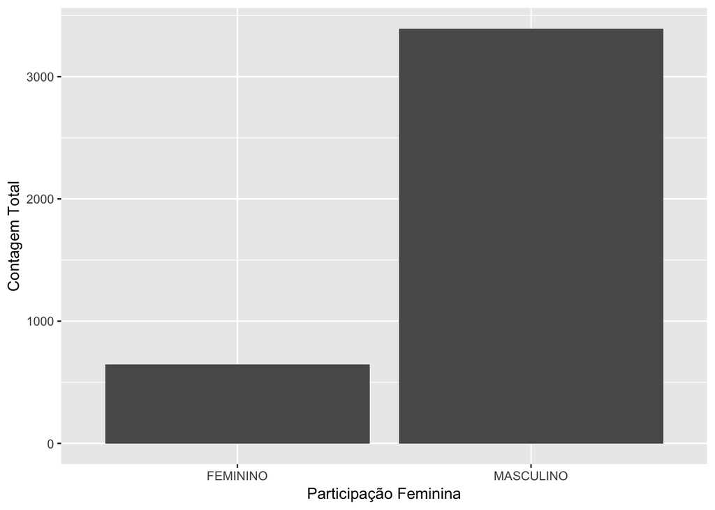

```r
eleicoes_2010 %>%
  group_by(sexo) %>%
  summarize(n = n()) %>%
  ggplot(aes(reorder(sexo,n), n)) +
  geom_bar(stat = "identity") +
  labs(x="Participação Feminina", y="Contagem Total")
```

**Apesar de muitas campanhas para a inclusão feminina dentro da câmara, a população ainda é de maioria masculina.**

### 3.1.2 Por partido também em esfera nacional

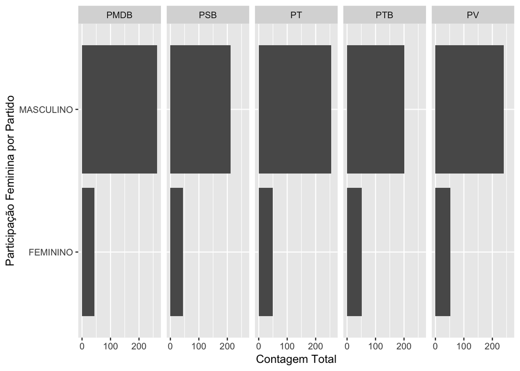

```r
parties_with_more_candidates_data = eleicoes_2010 %>%
  group_by(partido) %>%
  summarise(num = n()) %>%
  top_n(5, num)

eleicoes_2010 %>%
  filter(partido %in%  parties_with_more_candidates_data$partido) %>%
  group_by(partido, sexo, ano) %>%
  summarise(num = n()) %>%
  ggplot(aes(reorder(sexo, num), num)) +
  geom_bar(stat = "identity") + coord_flip()+
  labs(x="Participação Feminina por Partido",
       y="Contagem Total") +
  facet_grid(. ~partido)
```

**O mesmo ocorre no cenário dos partidos, sendo em sua totalidade, também compostos em sua maioria por homens. Até mesmo os partidos que pregam a diversidade também não apresentam certa representatividade feminina na câmara.**

## 3.2 Escolaridade dos candidatos

Como podemos observar no gráfico abaixo, A maioria dos candidatos possuem pelo ensino Superior ou mais. Isso pode ser uma notícia ate animadora.

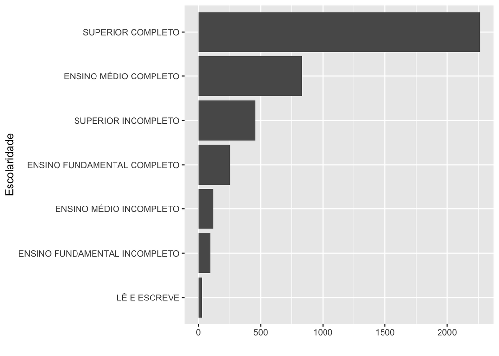

```r
# escolaridade
escolaridade = eleicoes_2010 %>%
  group_by(grau, ano) %>%
  summarise(num = n())

escolaridade %>%
  ggplot(aes(x = reorder(grau, num), y = num)) +
  geom_col() +
    labs(x="Escolaridade",
       y="") +
  coord_flip()
```

**O gráfico acima mostra um resultado promissor, tendo que a liderança dos candidatos tem o superior completo, isso tende a mostrar que os candidatos podem ter um conchecimento técnico mais aprofundado sobre determinadas leis orgânicas e regimentos internos da casa.**

## 3.3 Ocupações dos cadidatos

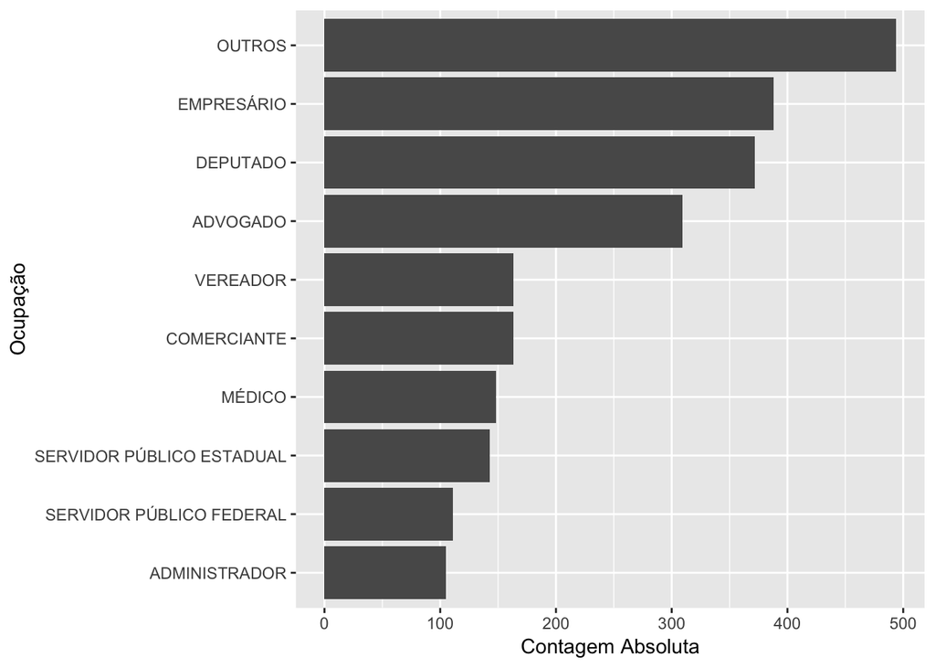

```r
ocupacao_candidatos = eleicoes_2010 %>%
  group_by(ocupacao) %>%
  summarise(num = n()) %>%
  top_n(10, num)

ocupacao_candidatos %>%
  ggplot(aes(x = reorder(ocupacao, num), y = num)) +
  geom_col() +
labs(x="Ocupação",
       y="Contagem Absoluta") +
  coord_flip()
```

# 4 Análise de Regressão Linear

## 4.1 Transfromação e limpesa dos Dados

### 4.1.1 Transfromando os dados (Codificação)

```r
eleicoes_2010$partido = as.factor(eleicoes_2010$partido)
eleicoes_2010$partido = as.numeric(eleicoes_2010$partido)
eleicoes_2010$sexo = as.factor(eleicoes_2010$sexo)
eleicoes_2010$sexo = as.numeric(eleicoes_2010$sexo)
eleicoes_2010$grau = as.factor(eleicoes_2010$grau)
eleicoes_2010$grau = as.numeric(eleicoes_2010$grau)
eleicoes_2010$estado_civil = as.factor(eleicoes_2010$estado_civil)
eleicoes_2010$estado_civil = as.numeric(eleicoes_2010$estado_civil)
eleicoes_2010$ocupacao = as.factor(eleicoes_2010$ocupacao)
eleicoes_2010$ocupacao = as.numeric(eleicoes_2010$ocupacao)
```

#### 4.1.1.1 Desconsiderando dados indisponiveis, caso haja.

```r
eleicoes_2010 <- na.omit(eleicoes_2010)
```

## 4.2 verficando os tipos das minhas colunas

```r
sapply(eleicoes_2010 , class)
```

```
##                           ano          sequencial_candidato
##                     "integer"                   "character"
##                          nome                            uf
##                   "character"                   "character"
##                       partido            quantidade_doacoes
##                     "numeric"                     "integer"
##           quantidade_doadores                 total_receita
##                     "integer"                     "numeric"
##                 media_receita   recursos_de_pessoas_fisicas
##                     "numeric"                     "numeric"
## recursos_de_pessoas_juridicas             recursos_proprios
##                     "numeric"                     "numeric"
##  recursos_de_partido_politico           quantidade_despesas
##                     "numeric"                     "integer"
##       quantidade_fornecedores                 total_despesa
##                     "integer"                     "numeric"
##                 media_despesa                         cargo
##                     "numeric"                   "character"
##                          sexo                          grau
##                     "numeric"                     "numeric"
##                  estado_civil                      ocupacao
##                     "numeric"                     "numeric"
##                         votos recursos_de_outros_candidatos
##                     "integer"                     "numeric"
```

### 4.2.1 Vamos descartar também outros dados que são inrelevantes para esse estudo

```r
eleicoes_2010 <- select(eleicoes_2010, -ano, -cargo, -nome, -sequencial_candidato, -uf)
```

## 4.3 Escolhendo o melhor modelo

### 4.3.1 Modelo Inicial

```r
arm2010 <- lm(votos ~ ., data=eleicoes_2010)
summary(arm2010)
```

```
##
## Call:
## lm(formula = votos ~ ., data = eleicoes_2010)
##
## Residuals:
##     Min      1Q  Median      3Q     Max
## -214030   -9620   -5815    -846 1299542
##
## Coefficients:
##                                 Estimate Std. Error t value Pr(>|t|)
## (Intercept)                    8.799e+03  4.024e+03   2.187 0.028810 *
## partido                       -2.297e+02  7.589e+01  -3.027 0.002483 **
## quantidade_doacoes             2.757e+01  5.417e+01   0.509 0.610768
## quantidade_doadores           -1.019e+01  6.282e+01  -0.162 0.871172
## total_receita                 -3.910e+01  8.354e+01  -0.468 0.639775
## media_receita                 -1.996e-01  5.400e-02  -3.696 0.000222 ***
## recursos_de_pessoas_fisicas    3.914e+01  8.354e+01   0.469 0.639438
## recursos_de_pessoas_juridicas  3.909e+01  8.354e+01   0.468 0.639878
## recursos_proprios              3.906e+01  8.354e+01   0.468 0.640100
## recursos_de_partido_politico   3.909e+01  8.354e+01   0.468 0.639834
## quantidade_despesas            1.356e+01  9.120e+00   1.487 0.136975
## quantidade_fornecedores       -3.082e+01  1.113e+01  -2.769 0.005650 **
## total_despesa                  8.476e-02  9.992e-03   8.483  < 2e-16 ***
## media_despesa                  1.621e-01  8.969e-02   1.807 0.070824 .
## sexo                           2.430e+03  1.628e+03   1.493 0.135609
## grau                           9.515e+02  3.387e+02   2.809 0.004987 **
## estado_civil                  -1.316e+03  4.604e+02  -2.858 0.004279 **
## ocupacao                      -4.902e+01  1.362e+01  -3.598 0.000325 ***
## recursos_de_outros_candidatos  3.910e+01  8.354e+01   0.468 0.639793
## ---
## Signif. codes:  0 '***' 0.001 '**' 0.01 '*' 0.05 '.' 0.1 ' ' 1
##
## Residual standard error: 37140 on 4021 degrees of freedom
## Multiple R-squared:  0.4408, Adjusted R-squared:  0.4383
## F-statistic: 176.1 on 18 and 4021 DF,  p-value: < 2.2e-16
```

### 4.3.2 Modelo 1

```r
modelo1 <- lm(formula = votos ~ partido + quantidade_doacoes + total_receita+ media_receita+ recursos_de_outros_candidatos + recursos_de_pessoas_fisicas + recursos_de_pessoas_juridicas + recursos_proprios+recursos_de_partido_politico + quantidade_despesas + quantidade_fornecedores + total_despesa + media_despesa + sexo + grau+estado_civil + ocupacao, data=eleicoes_2010)
summary(modelo1)
```

```
##
## Call:
## lm(formula = votos ~ partido + quantidade_doacoes + total_receita +
##     media_receita + recursos_de_outros_candidatos + recursos_de_pessoas_fisicas +
##     recursos_de_pessoas_juridicas + recursos_proprios + recursos_de_partido_politico +
##     quantidade_despesas + quantidade_fornecedores + total_despesa +
##     media_despesa + sexo + grau + estado_civil + ocupacao, data = eleicoes_2010)
##
## Residuals:
##     Min      1Q  Median      3Q     Max
## -216300   -9627   -5815    -860 1299577
##
## Coefficients:
##                                 Estimate Std. Error t value Pr(>|t|)
## (Intercept)                    8.809e+03  4.023e+03   2.190 0.028581 *
## partido                       -2.297e+02  7.588e+01  -3.027 0.002483 **
## quantidade_doacoes             1.882e+01  4.984e+00   3.777 0.000161 ***
## total_receita                 -3.918e+01  8.352e+01  -0.469 0.639045
## media_receita                 -1.990e-01  5.389e-02  -3.693 0.000225 ***
## recursos_de_outros_candidatos  3.918e+01  8.352e+01   0.469 0.639062
## recursos_de_pessoas_fisicas    3.922e+01  8.352e+01   0.470 0.638710
## recursos_de_pessoas_juridicas  3.917e+01  8.352e+01   0.469 0.639148
## recursos_proprios              3.914e+01  8.352e+01   0.469 0.639369
## recursos_de_partido_politico   3.917e+01  8.352e+01   0.469 0.639103
## quantidade_despesas            1.371e+01  9.072e+00   1.512 0.130675
## quantidade_fornecedores       -3.101e+01  1.107e+01  -2.801 0.005113 **
## total_despesa                  8.458e-02  9.933e-03   8.516  < 2e-16 ***
## media_despesa                  1.616e-01  8.964e-02   1.803 0.071406 .
## sexo                           2.426e+03  1.628e+03   1.490 0.136199
## grau                           9.513e+02  3.386e+02   2.809 0.004988 **
## estado_civil                  -1.316e+03  4.604e+02  -2.859 0.004267 **
## ocupacao                      -4.912e+01  1.361e+01  -3.609 0.000311 ***
## ---
## Signif. codes:  0 '***' 0.001 '**' 0.01 '*' 0.05 '.' 0.1 ' ' 1
##
## Residual standard error: 37140 on 4022 degrees of freedom
## Multiple R-squared:  0.4408, Adjusted R-squared:  0.4384
## F-statistic: 186.5 on 17 and 4022 DF,  p-value: < 2.2e-16
```

### 4.3.3 Modelo 2

```r
modelo2 <- lm(formula = votos ~ partido + quantidade_doacoes + total_receita+ media_receita+ recursos_de_outros_candidatos + recursos_de_pessoas_fisicas + recursos_de_pessoas_juridicas + recursos_de_partido_politico + quantidade_despesas + quantidade_fornecedores + total_despesa + media_despesa + sexo + grau+estado_civil + ocupacao, data=eleicoes_2010)
summary(modelo2)
```

```
##
## Call:
## lm(formula = votos ~ partido + quantidade_doacoes + total_receita +
##     media_receita + recursos_de_outros_candidatos + recursos_de_pessoas_fisicas +
##     recursos_de_pessoas_juridicas + recursos_de_partido_politico +
##     quantidade_despesas + quantidade_fornecedores + total_despesa +
##     media_despesa + sexo + grau + estado_civil + ocupacao, data = eleicoes_2010)
##
## Residuals:
##     Min      1Q  Median      3Q     Max
## -216288   -9624   -5814    -869 1299592
##
## Coefficients:
##                                 Estimate Std. Error t value Pr(>|t|)
## (Intercept)                    8.812e+03  4.022e+03   2.191 0.028516 *
## partido                       -2.303e+02  7.586e+01  -3.036 0.002414 **
## quantidade_doacoes             1.882e+01  4.983e+00   3.776 0.000162 ***
## total_receita                 -3.788e-02  9.451e-03  -4.008 6.24e-05 ***
## media_receita                 -1.988e-01  5.389e-02  -3.689 0.000228 ***
## recursos_de_outros_candidatos  3.594e-02  5.695e-03   6.311 3.07e-10 ***
## recursos_de_pessoas_fisicas    7.706e-02  9.564e-03   8.057 1.02e-15 ***
## recursos_de_pessoas_juridicas  2.590e-02  4.266e-03   6.071 1.39e-09 ***
## recursos_de_partido_politico   3.108e-02  4.983e-03   6.237 4.91e-10 ***
## quantidade_despesas            1.372e+01  9.071e+00   1.513 0.130442
## quantidade_fornecedores       -3.100e+01  1.107e+01  -2.801 0.005111 **
## total_despesa                  8.455e-02  9.932e-03   8.514  < 2e-16 ***
## media_despesa                  1.613e-01  8.963e-02   1.799 0.072034 .
## sexo                           2.422e+03  1.627e+03   1.488 0.136784
## grau                           9.502e+02  3.386e+02   2.806 0.005035 **
## estado_civil                  -1.314e+03  4.603e+02  -2.855 0.004325 **
## ocupacao                      -4.897e+01  1.360e+01  -3.600 0.000323 ***
## ---
## Signif. codes:  0 '***' 0.001 '**' 0.01 '*' 0.05 '.' 0.1 ' ' 1
##
## Residual standard error: 37140 on 4023 degrees of freedom
## Multiple R-squared:  0.4407, Adjusted R-squared:  0.4385
## F-statistic: 198.1 on 16 and 4023 DF,  p-value: < 2.2e-16
```

### 4.3.4 Modelo 3

```r
modelo3 <- lm(formula = votos ~ partido + quantidade_doacoes + total_receita+ media_receita+ recursos_de_outros_candidatos + recursos_de_pessoas_fisicas + recursos_de_pessoas_juridicas + recursos_de_partido_politico + quantidade_despesas + quantidade_fornecedores + total_despesa + media_despesa + grau+estado_civil + ocupacao, data=eleicoes_2010)
summary(modelo3)
```

```
##
## Call:
## lm(formula = votos ~ partido + quantidade_doacoes + total_receita +
##     media_receita + recursos_de_outros_candidatos + recursos_de_pessoas_fisicas +
##     recursos_de_pessoas_juridicas + recursos_de_partido_politico +
##     quantidade_despesas + quantidade_fornecedores + total_despesa +
##     media_despesa + grau + estado_civil + ocupacao, data = eleicoes_2010)
##
## Residuals:
##     Min      1Q  Median      3Q     Max
## -216775   -9655   -5776    -858 1299865
##
## Coefficients:
##                                 Estimate Std. Error t value Pr(>|t|)
## (Intercept)                    1.356e+04  2.445e+03   5.547 3.09e-08 ***
## partido                       -2.325e+02  7.586e+01  -3.065 0.002193 **
## quantidade_doacoes             1.901e+01  4.982e+00   3.815 0.000138 ***
## total_receita                 -3.766e-02  9.451e-03  -3.985 6.88e-05 ***
## media_receita                 -1.978e-01  5.389e-02  -3.670 0.000246 ***
## recursos_de_outros_candidatos  3.573e-02  5.694e-03   6.274 3.88e-10 ***
## recursos_de_pessoas_fisicas    7.719e-02  9.565e-03   8.070 9.22e-16 ***
## recursos_de_pessoas_juridicas  2.587e-02  4.266e-03   6.064 1.45e-09 ***
## recursos_de_partido_politico   3.100e-02  4.984e-03   6.219 5.50e-10 ***
## quantidade_despesas            1.385e+01  9.072e+00   1.526 0.126985
## quantidade_fornecedores       -3.126e+01  1.107e+01  -2.824 0.004764 **
## total_despesa                  8.450e-02  9.933e-03   8.507  < 2e-16 ***
## media_despesa                  1.623e-01  8.964e-02   1.810 0.070302 .
## grau                           9.387e+02  3.385e+02   2.773 0.005586 **
## estado_civil                  -1.433e+03  4.534e+02  -3.160 0.001587 **
## ocupacao                      -4.912e+01  1.361e+01  -3.610 0.000310 ***
## ---
## Signif. codes:  0 '***' 0.001 '**' 0.01 '*' 0.05 '.' 0.1 ' ' 1
##
## Residual standard error: 37140 on 4024 degrees of freedom
## Multiple R-squared:  0.4404, Adjusted R-squared:  0.4383
## F-statistic: 211.1 on 15 and 4024 DF,  p-value: < 2.2e-16
```

### 4.3.5 Modelo 4

```r
modelo4 <- lm(formula = votos ~ partido + quantidade_doacoes + total_receita+ media_receita+ recursos_de_outros_candidatos + recursos_de_pessoas_fisicas + recursos_de_pessoas_juridicas + recursos_de_partido_politico + quantidade_fornecedores + total_despesa + media_despesa + grau+estado_civil + ocupacao, data=eleicoes_2010)
summary(modelo4)
```

```
##
## Call:
## lm(formula = votos ~ partido + quantidade_doacoes + total_receita +
##     media_receita + recursos_de_outros_candidatos + recursos_de_pessoas_fisicas +
##     recursos_de_pessoas_juridicas + recursos_de_partido_politico +
##     quantidade_fornecedores + total_despesa + media_despesa +
##     grau + estado_civil + ocupacao, data = eleicoes_2010)
##
## Residuals:
##     Min      1Q  Median      3Q     Max
## -222244   -9681   -5827    -806 1299481
##
## Coefficients:
##                                 Estimate Std. Error t value Pr(>|t|)
## (Intercept)                    1.356e+04  2.446e+03   5.543 3.16e-08 ***
## partido                       -2.329e+02  7.587e+01  -3.070 0.002153 **
## quantidade_doacoes             1.883e+01  4.982e+00   3.780 0.000159 ***
## total_receita                 -3.107e-02  8.408e-03  -3.695 0.000223 ***
## media_receita                 -1.999e-01  5.388e-02  -3.711 0.000209 ***
## recursos_de_outros_candidatos  3.608e-02  5.690e-03   6.341 2.53e-10 ***
## recursos_de_pessoas_fisicas    7.556e-02  9.507e-03   7.948 2.45e-15 ***
## recursos_de_pessoas_juridicas  2.643e-02  4.252e-03   6.215 5.64e-10 ***
## recursos_de_partido_politico   3.082e-02  4.983e-03   6.184 6.87e-10 ***
## quantidade_fornecedores       -1.488e+01  2.707e+00  -5.495 4.14e-08 ***
## total_despesa                  7.729e-02  8.739e-03   8.845  < 2e-16 ***
## media_despesa                  1.652e-01  8.963e-02   1.843 0.065354 .
## grau                           9.500e+02  3.385e+02   2.806 0.005034 **
## estado_civil                  -1.448e+03  4.534e+02  -3.195 0.001410 **
## ocupacao                      -4.889e+01  1.361e+01  -3.593 0.000330 ***
## ---
## Signif. codes:  0 '***' 0.001 '**' 0.01 '*' 0.05 '.' 0.1 ' ' 1
##
## Residual standard error: 37150 on 4025 degrees of freedom
## Multiple R-squared:  0.4401, Adjusted R-squared:  0.4381
## F-statistic:   226 on 14 and 4025 DF,  p-value: < 2.2e-16
```

### 4.3.6 Modelo 5

```r
modelo5 <- lm(formula = votos ~ partido + quantidade_doacoes + total_receita+ media_receita+ recursos_de_outros_candidatos + recursos_de_pessoas_fisicas + recursos_de_pessoas_juridicas + recursos_de_partido_politico + quantidade_fornecedores + total_despesa  + grau+estado_civil + ocupacao, data=eleicoes_2010)
summary(modelo5)
```

```
##
## Call:
## lm(formula = votos ~ partido + quantidade_doacoes + total_receita +
##     media_receita + recursos_de_outros_candidatos + recursos_de_pessoas_fisicas +
##     recursos_de_pessoas_juridicas + recursos_de_partido_politico +
##     quantidade_fornecedores + total_despesa + grau + estado_civil +
##     ocupacao, data = eleicoes_2010)
##
## Residuals:
##     Min      1Q  Median      3Q     Max
## -224391   -9622   -5811    -846 1299407
##
## Coefficients:
##                                 Estimate Std. Error t value Pr(>|t|)
## (Intercept)                    1.349e+04  2.446e+03   5.515 3.70e-08 ***
## partido                       -2.297e+02  7.587e+01  -3.027 0.002484 **
## quantidade_doacoes             1.982e+01  4.954e+00   4.002 6.40e-05 ***
## total_receita                 -3.222e-02  8.387e-03  -3.841 0.000124 ***
## media_receita                 -1.406e-01  4.322e-02  -3.253 0.001150 **
## recursos_de_outros_candidatos  3.612e-02  5.692e-03   6.345 2.47e-10 ***
## recursos_de_pessoas_fisicas    7.752e-02  9.451e-03   8.203 3.13e-16 ***
## recursos_de_pessoas_juridicas  2.710e-02  4.237e-03   6.397 1.76e-10 ***
## recursos_de_partido_politico   3.123e-02  4.979e-03   6.271 3.96e-10 ***
## quantidade_fornecedores       -1.513e+01  2.704e+00  -5.597 2.33e-08 ***
## total_despesa                  7.719e-02  8.741e-03   8.831  < 2e-16 ***
## grau                           9.473e+02  3.386e+02   2.798 0.005174 **
## estado_civil                  -1.430e+03  4.534e+02  -3.154 0.001622 **
## ocupacao                      -4.844e+01  1.361e+01  -3.560 0.000376 ***
## ---
## Signif. codes:  0 '***' 0.001 '**' 0.01 '*' 0.05 '.' 0.1 ' ' 1
##
## Residual standard error: 37160 on 4026 degrees of freedom
## Multiple R-squared:  0.4396, Adjusted R-squared:  0.4378
## F-statistic:   243 on 13 and 4026 DF,  p-value: < 2.2e-16
```

```r
eleicoes_2010_modelo <- select(eleicoes_2010,grau, estado_civil,ocupacao, partido,quantidade_doacoes,total_receita,media_receita,recursos_de_outros_candidatos,recursos_de_pessoas_fisicas,recursos_de_pessoas_juridicas,recursos_de_partido_politico,quantidade_fornecedores,total_despesa, votos)
```

## 4.4 Correlacão entre as variáveis

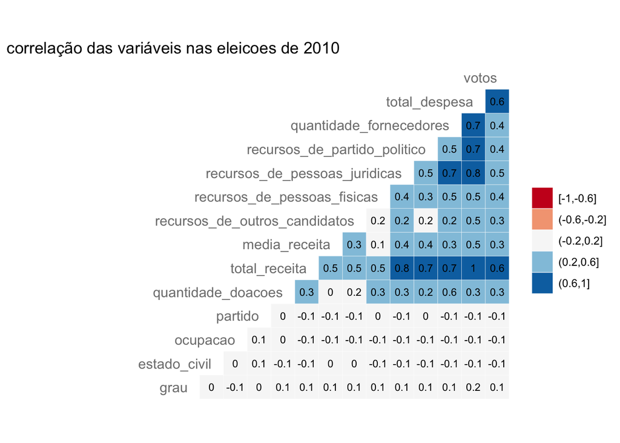

```r
eleicoes_2010_modelo %>%
  ggcorr(palette = "RdBu",
         color = "grey50",
         label = TRUE, hjust = 1,
         label_size = 3, size = 4,
         nbreaks = 5, layout.exp = 7) +
  ggtitle("correlação das variáveis nas eleicoes de 2010")
```

```r
eleicoes_2010_modelo <- select(eleicoes_2010,quantidade_doacoes,total_receita,media_receita,recursos_de_outros_candidatos,recursos_de_pessoas_fisicas,recursos_de_pessoas_juridicas,recursos_de_partido_politico,quantidade_fornecedores,total_despesa, votos)
```

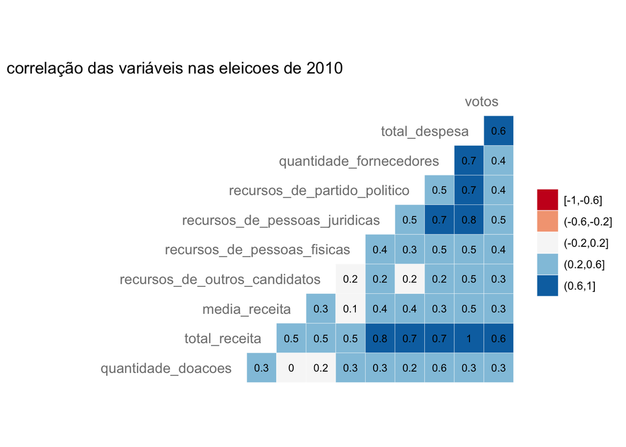

```r
eleicoes_2010_modelo %>%
  ggcorr(palette = "RdBu",
         color = "grey50",
         label = TRUE, hjust = 1,
         label_size = 3, size = 4,
         nbreaks = 5, layout.exp = 7) +
  ggtitle("correlação das variáveis nas eleicoes de 2010")
```

```r
modelo6 <- lm(votos ~ total_despesa + total_receita + recursos_de_pessoas_juridicas , data= eleicoes_2010_modelo)
summary(modelo6)
```

```
##
## Call:
## lm(formula = votos ~ total_despesa + total_receita + recursos_de_pessoas_juridicas,
##     data = eleicoes_2010_modelo)
##
## Residuals:
##     Min      1Q  Median      3Q     Max
## -236751   -8674   -7862   -3296 1307279
##
## Coefficients:
##                                 Estimate Std. Error t value Pr(>|t|)
## (Intercept)                    8.828e+03  6.516e+02  13.548  < 2e-16 ***
## total_despesa                  8.674e-02  8.797e-03   9.861  < 2e-16 ***
## total_receita                 -2.413e-02  7.996e-03  -3.018  0.00256 **
## recursos_de_pessoas_juridicas  1.196e-02  3.851e-03   3.105  0.00192 **
## ---
## Signif. codes:  0 '***' 0.001 '**' 0.01 '*' 0.05 '.' 0.1 ' ' 1
##
## Residual standard error: 38170 on 4036 degrees of freedom
## Multiple R-squared:  0.4073, Adjusted R-squared:  0.4069
## F-statistic: 924.6 on 3 and 4036 DF,  p-value: < 2.2e-16
```

# 5 Análise de Resíduos

Chamamos de Análise dos Resíduos um conjunto de técnicas utilizadas para investigar a adequabilidade de um modelo de regressão com base nos resíduos. Resíduo é o nome dado pela diferença entre os valores observados e os valores ajustados pelo modelo. Considerando o modelo:

> y = Xβ + e

onde:

- X = Variável explicativas
- β = Coeficiente estimado
- e = erro

Análises que iremos fazer são:

- Normalidade: A análise visa, fundamentalmente, verificar se os resíduos são normalmente distribuídos;
- Homogeneidade: A análise visa, fundamentalmente, verificar se os resíduos variam na mesma proporsão;
- Independência: A análise visa, fundamentalmente, verificar se existe uma diferença significativa entre as médias e se os fatores exercem influência em alguma variável dependente;
- Análise de variância: A análise visa, fundamentalmente, verificar se existe uma diferença significativa entre as médias e se os fatores exercem influência em alguma variável dependente.

## 5.1 Teste de Nomalidade

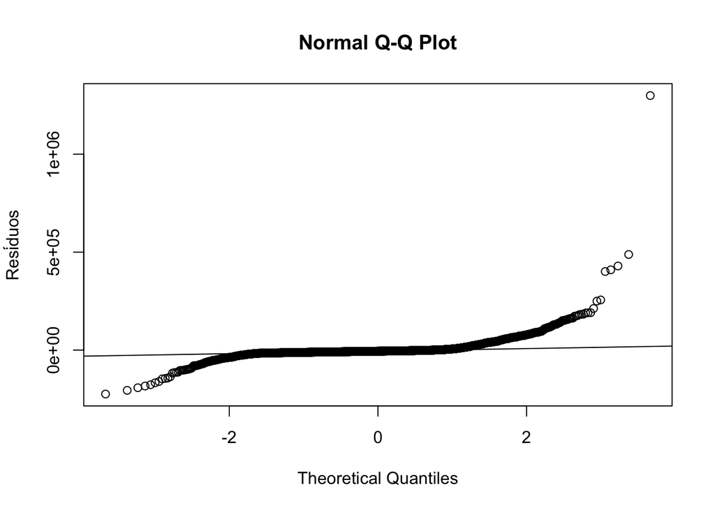

```r
qqnorm(residuals(modelo5), ylab="Resíduos")
qqline(residuals(modelo5))
```

```r
shapiro.test(residuals(modelo5))
```

```
##
##  Shapiro-Wilk normality test
##
## data:  residuals(modelo5)
## W = 0.42985, p-value < 2.2e-16
```

**Os testes de normalidade são utilizados para verificar se a distribuição de probabilidade associada a um conjunto de dados pode ser aproximada pela distribuição normal.**

## 5.2 Teste de Homogeneidade

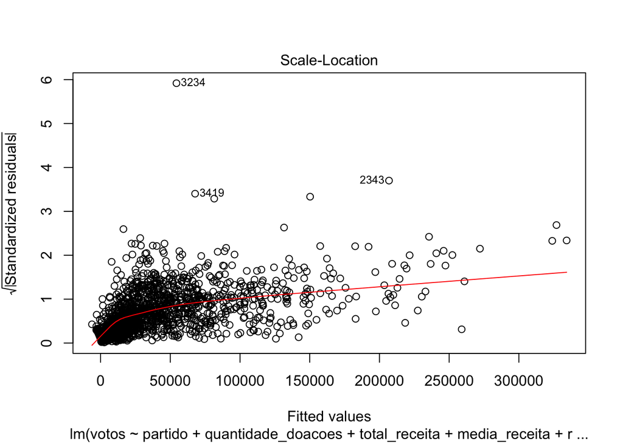

```r
plot(modelo5, which=3)
```

```r
bptest(modelo5)
```

```
##
##  studentized Breusch-Pagan test
##
## data:  modelo5
## BP = 64.651, df = 13, p-value = 7.628e-09
```

**Homocedasticidade é o termo para designar variância constante dos erros experimentais para observações distintas.**

**Como o BP = 64.651, encontramos então os resíduos padronizados.**

## 5.3 Teste de Independência

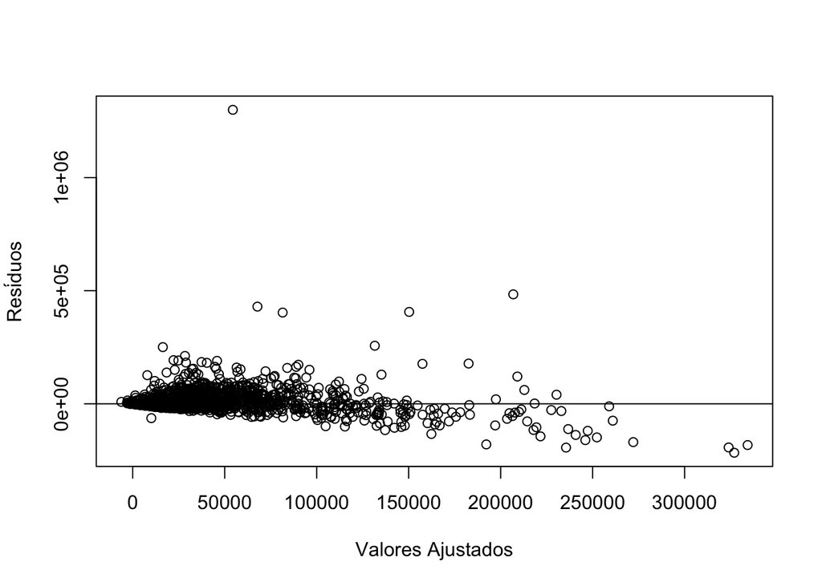

```r
plot(fitted(modelo5),residuals(modelo1),xlab="Valores Ajustados",ylab="Resíduos")
abline(h=0)
```

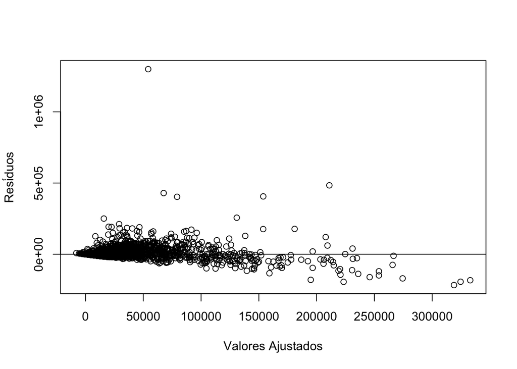

```r
plot(fitted(modelo1),residuals(modelo1),xlab="Valores Ajustados",ylab="Resíduos")
abline(h=0)
```

**Análise de variância é a técnica estatística que permite avaliar afirmações sobre as médias de populações. A análise visa, fundamentalmente, verificar se existe uma diferença significativa entre as médias e se os fatores exercem influência em alguma variável dependente.**